# Right Wing Authoritarianism

The data is available in the file rwa.csv. This dataset comes from https://openpsychometrics.org/_rawdata/. It measures how people score on a measure called Right Wing Authoritarianism, or RWA.

### Cleaning Notes

- People’s overall RWA score is the mean of questions 3 to 22. Questions 1 and 2 are warm up questions.
- The following questions were reverse scored: 4, 6, 8, 9, 11, 13, 15, 18, 20, 21. I have reversed that back (9 - score).

### Analysis Questions

#### What’s the average RWA score for each gender?

```r
rwa %>%
  group_by(gender) %>%
  summarise(av_rwa = mean(rwa_score))
```

| gender | av_rwa |
| --- | --- |
| Female | 5.127452 |
| Male | 5.096106 |
| Other | 5.026667 |
| NA | 5.207895 |

#### What’s the average RWA score for left handed people vs. right handed people.

```r
rwa %>%
  group_by(hand) %>%
  summarise(av_rwa = mean(rwa_score))
```

| hand | av_rwa |
| --- | --- |
| Left | 5.120776 |
| Other | 5.172442 |
| Right | 5.101280 |
| NA | 5.110417 |

#### What’s the average family size for each type of childhood?

```r
rwa %>%
  group_by(upbringing) %>%
  summarise(av_family_size = mean(familysize))
```

| upbringing | av_family_size |
| --- | --- |
| Rural | 2.792988 |
| Suburban | 2.622197 |
| Urban | 2.497587 |
| NA | 2.548673 |

#### What’s the average time to take the test for each education level?

```r
time_by_education <- rwa %>%
  group_by(education) %>%
  summarise(av_test_time = mean(test_time))

time_by_education
```

| education | av_test_time |
| --- | --- |
| Below Secondary | 380.4805 |
| Postgraduate | 330.0297 |
| Secondary | 512.4967 |
| University | 623.3965 |
| NA | 5294.5980 |

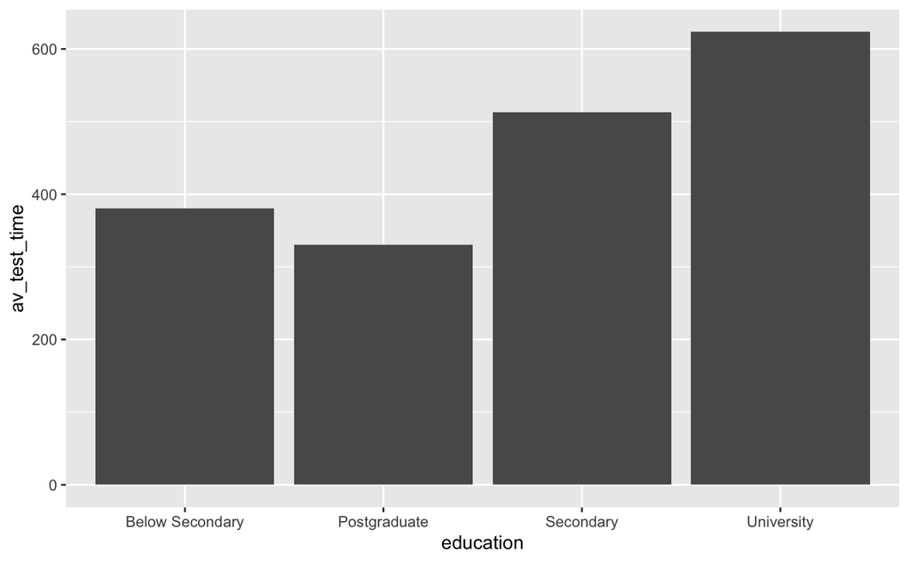

```r
time_by_education %>%
  filter(!is.na(education)) %>%
ggplot(aes(x = education, y = av_test_time)) + geom_col()
```

#### What’s the average RWA score for people in the age brakets?

```r
rwa %>%
  group_by(age_bracket) %>%
  summarise(av_rwa = mean(rwa_score)) %>%
  arrange(age_bracket)
```

| age_bracket | av_rwa |
| --- | --- |
| 18 to 25 | 5.148775 |
| 26 to 40 | 5.052406 |
| 41 to 60 | 4.999083 |
| Over 60 | 4.898970 |
| Under 18 | 5.323390 |

### Further Information

This data was collected through an interactive on-line version of the Right-wing Authoritarianism Scale in 2015. Visitors completed the test primarily for personal amusement. At the end of the test but before the results were displayed, users were asked if they would be willing to complete an additional survey and allow their responses to be saved for research. Only users who agreed yes are in this dataset. Individuals with age < 13 were not recorded.

The responses to the RWAS are in (question numbers match to items in Altemeyer, Bob (2007). The Authoritarians. University of Manitoba.):

Q1 - Q22

The time spent answering each question was also recorded, and are stored in variables

E1 - E22

The other following time elapses were also recorded:

introelapse The time spent on the introduction/landing page (in seconds) testelapse The time spent on the RWAS questions surveyelapse The time spent answering the rest of the demographic and survey questions

The Ten Item Personality Inventory was administered (see Gosling, S. D., Rentfrow, P. J., & Swann, W. B., Jr. (2003). A Very Brief Measure of the Big Five Personality Domains. Journal of Research in Personality, 37, 504-528.):

TIPI1 Extraverted, enthusiastic. TIPI2 Critical, quarrelsome. TIPI3 Dependable, self-disciplined. TIPI4 Anxious, easily upset. TIPI5 Open to new experiences, complex. TIPI6 Reserved, quiet. TIPI7 Sympathetic, warm. TIPI8 Disorganized, careless. TIPI9 Calm, emotionally stable. TIPI10 Conventional, uncreative.

The TIPI items were rated “I see myself as:” _____ such that

1 = Disagree strongly 2 = Disagree moderately 3 = Disagree a little 4 = Neither agree nor disagree 5 = Agree a little 6 = Agree moderately 7 = Agree strongly

The following items were presented as a check-list and subjects were instructed “In the grid below, check all the words whose definitions you are sure you know”:

VCL1 boat VCL2 incoherent VCL3 pallid VCL4 robot VCL5 audible VCL6 cuivocal VCL7 paucity VCL8 epistemology VCL9 florted VCL10 decide VCL11 pastiche VCL12 verdid VCL13 abysmal VCL14 lucid VCL15 betray VCL16 funny

A value of 1 is checked, 0 means unchecked. The words at VCL6, VCL9, and VCL12 are not real words and can be used as a validity check.

A bunch more questions were then asked:

education “How much education have you completed?”, 1=Less than high school, 2=High school, 3=University degree, 4=Graduate degree urban “What type of area did you live when you were a child?”, 1=Rural (country side), 2=Suburban, 3=Urban (town, city) gender “What is your gender?”, 1=Male, 2=Female, 3=Other engnat “Is English your native language?”, 1=Yes, 2=No age “How many years old are you?” hand “What hand do you use to write with?”, 1=Right, 2=Left, 3=Both religion “What is your religion?”, 1=Agnostic, 2=Atheist, 3=Buddhist, 4=Christian (Catholic), 5=Christian (Mormon), 6=Christian (Protestant), 7=Christian (Other), 8=Hindu, 9=Jewish, 10=Muslim, 11=Sikh, 12=Other orientation “What is your sexual orientation?”, 1=Heterosexual, 2=Bisexual, 3=Homosexual, 4=Asexual, 5=Other race “What is your race?”, 1=Asian, 2=Arab, 3=Black, 4=Indigenous Australian, Native American or White***, 5=Other voted “Have you voted in a national election in the past year?”, 1=Yes, 2=No married “What is your marital status?”, 1=Never married, 2=Currently married, 3=Previously married familysize “Including you, how many children did your mother have?”  
major “If you attended a university, what was your major (e.g. ”psychology”, “English”, “civil engineering”)?”

***There was an error in the coding of they survey, these options were separate but all were given the same numerical value

The dimensions of the users screen were also recorded:

screenw Obtained from javascript:screen.width screenh Obtained from javascript:screen.height